# concepts

# *R basic concept*

1. indexing  
   all indexing in R is from 1 not 0  
   the slicing (eg 1:3): start and end are included
2. R language is case sensitive.
3. R operations are vector based, performs on each element of vector.

# *Variable naming Conventions*

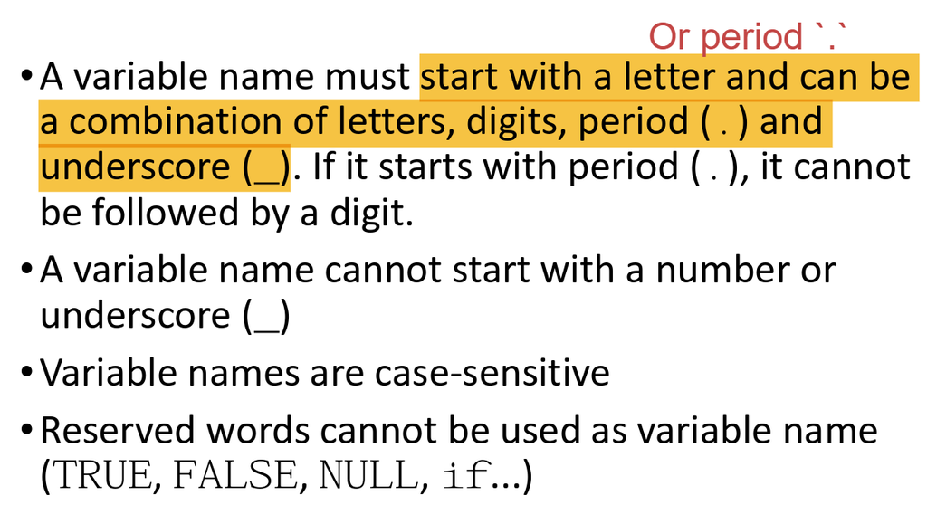

# *datatype*

## **1. data type intro**

common data type: numeric, logical, character

1. numeric  
   Includes both both int and float (they have different classes like `integer` or `numeric` (which is double), but the mode is all `numeric`) Note: to explicitly name integer, use suffix `L`, eg `1L` means integer 1
2. character  
   String or character (like python), denoted by double quote `"` or single quote `'` no diff
3. logical  
   `TRUE` and `FALSE`, can also `T` and `F`

## **2. Inspect data type**

1. `mode()`  
   describe the data type used for storage.  
   Only(?) have: `numeric, logical, character`, etc.
2. `class()`  
   describe the object class of the input variable  
   e.g., `numeric` (here numeric is “double”, differen), `integer`, `list`, `matrix`, `factor`, etc.
3. egs

   ```
   > mode(1L); class(1L)
   [1] "numeric"
   [1] "integer"

   > mode(factor(c("a","b"))); class(factor(c("a","b")))
   [1] "numeric"
   [1] "factor"

   > mode(matrix(0,2,2)); class(matrix(0,2,2))
   [1] "numeric"
   [1] "matrix"

   # the class of basic vectors (only the numeric has a difference)
   > class(1)
   [1] "numeric"
   > class(1L)
   [1] "integer"
   > class(T)
   [1] "logical"
   > class("a")
   [1] "character"

   # the return class of both mode and class is "character"
   > class(mode(1))
   [1] "character"
   > class(class(1))
   [1] "character"
   ```

## **Special values**

### Missing value `NA`

1. Intro Missing values often arise in real data problems, but they can also arise because of the way calculations are performed.
2. Inspect: `is.na()`

## **Technical: storage of numbers**

lec1 49-50